# enaR Tutorial: Worked example for the Cone Springs model

Stuart R. Borrett[^1]

Last updated - 03 October 2017

# Introduction

This is a simplified tutorial for getting started with the **enaR** package. It illustrates how to apply selected Ecological Network Analyses (ENA) to single model. For brevity, this tutorial does not explain how to interpret the results; the user is directed to the literature for this. This tutorial uses the “Cone Springs” model to illustrate the analyses and some of the results. This model was also used by Ulanowicz for his [Netwrk 4.2 software manual](https://www.cbl.umces.edu/~ulan/ntwk/netwrk.txt), which may facillitate comparisons. For a more detialed description of the **enaR** software please see the [Vignette](https://cran.r-project.org/web/packages/enaR/vignettes/enaR-vignette.pdf) or [Borrett and Lau (2014)](http://onlinelibrary.wiley.com/doi/10.1111/2041-210X.12282/epdf).

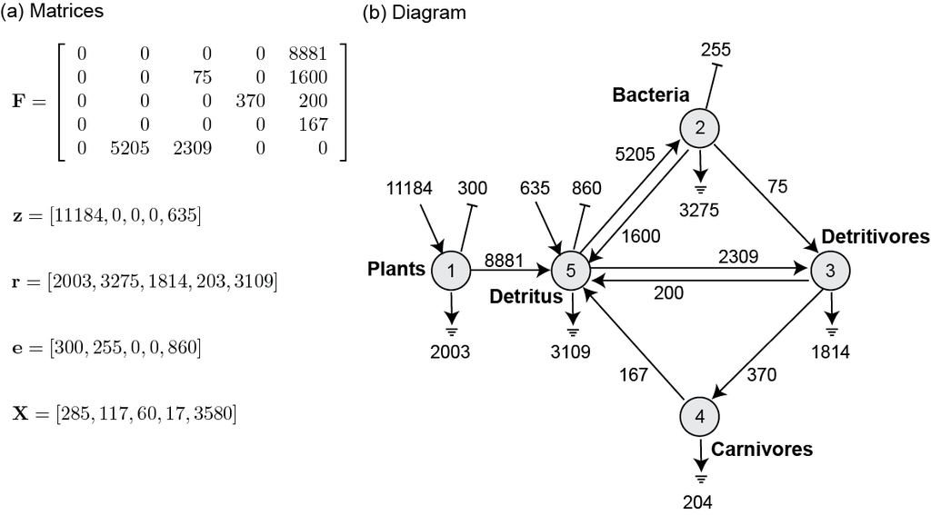

Cone Spring Model (Williams and Crouthamel, unpublished ms and Tilly 1968) with flows in units of kcal/m2/y: (a) model components in matrix form (F is the flow matrix, z is a vector of inputs, r is a vector of respiration values, e is a vector of exports, and X is a vector of storages or biomass values) and (b) shows the model information in diagram form.

## Preparing the Workspace

To get started using **enaR**, the first step is to load the library along with the **network** library as follows. It is also a good idea to clear the working memory when we start a new analysis

```r
rm(list = ls())  # clears the working memory
library(enaR)    # loads the enaR library
library(network) # loads the network library
```

# Entering a model

This software asssumes that the user has created a network model and is ready to analyze it. Fore ENA to make sense, users should follow the modeling guidelines in [Fath et al. (2007)](https://people.clas.ufl.edu/ulan/files/Fath.pdf) Thus, the first step is to enter a model, and there are several tools to help you accomplish this task. Here I illustrate (1) entering model data by hand and using the *pack()* fuction to create the network data object, and (2) selecting an existing model from the library of models distributed with *enaR*.

Users may have data stored in one of several common formats used by other ENA software. *enaR* can read in several of these model formats using functions like *read.scor()*, *read.EcoNet()*, *read.nea()*, and *read.neam()*. It also has several *write* functions to write models into other software input formats.

## Enter Model using *pack()*

As illustrated in the Cone Springs figure, the model information can be represented in both matrix (vector) format and in diagram form. We will use the matrix form to enter the data into *enaR*.

```r
# --- Enter Model Information ---
# enter flows as a vector, concatenating rows
f = c( 0,0,0,0, 8881, 0,0,75, 0, 1600, 0,0,0, 370, 200, 0,0,0,0, 167, 0, 5205, 2309, 0, 0)
F = matrix(f, nrow = 5, ncol = 5, byrow = TRUE) # create the flow matrix
# add the row and column names to F
rownames(F) = c('plants', 'bacteria',
                'detritivores', 'carnivores', 'detritus')
colnames(F) = rownames(F)

# inputs
z = c(11184, 0,0,0, 635)

# respirations
r = c(2003, 3275, 1814, 203, 3108)

# exports
e = c(300, 255, 0, 0, 860)

# storage (biomass in food web models)
biomass = c(285, 117, 60, 17, 3580)

# identify which nodes are living
liv = c(TRUE, TRUE, TRUE, TRUE, FALSE)

# --- build network data object for enaR ---

cone = pack(flow = F, input = z, respiration = r, export = e,
            storage = biomass, living = liv)
show(cone)
```

```
##  Network attributes:
##   vertices = 5
##   directed = TRUE
##   hyper = FALSE
##   loops = TRUE
##   multiple = FALSE
##   bipartite = FALSE
##   balanced = TRUE
##   total edges= 8
##     missing edges= 0
##     non-missing edges= 8
##
##  Vertex attribute names:
##     export input living output respiration storage vertex.names
##
##  Edge attribute names:
##     flow
```

```r
# determine if the model is at steady state (as expected)
ssCheck(cone)
```

```
## [1] TRUE
```

## Model Library

If you do not yet have your own model to analyze, you can use one from the *enaR* model library. This section shows you how to load the library, look at part of the list of model names included in the library, and then select the Cone Springs model for further analysis.

```r
data(enaModels)  # loads library of models (stored as a list)
model.names = names(enaModels)
model.names[c(6,9,20,36,47)]
```

```
## [1] "Cone Springs"            "Oyster Reef "
## [3] "Peruvian Upwelling"      "Narragansett Bay"
## [5] "Sylt-R{\\o}m{\\o} Bight"
```

```r
model = enaModels[["Cone Springs"]]  # selects the Cone Springs model.
model
```

```
##  Network attributes:
##   vertices = 5
##   directed = TRUE
##   hyper = FALSE
##   loops = TRUE
##   multiple = FALSE
##   bipartite = FALSE
##   balanced = TRUE
##   total edges= 8
##     missing edges= 0
##     non-missing edges= 8
##
##  Vertex attribute names:
##     export input living output respiration storage vertex.names
##
##  Edge attribute names:
##     flow
```

The model is stored as a network data object with attributes for the network, nodes (vertices), and edges.

As many (but not all) of the ENA algorithms assume that the model is at steady state, we should first check this condition.

```r
ssCheck(model)
```

```
## [1] TRUE
```

This model is at steady-state. If it had not been, we could have applied the *balance()* function to apply one of several automated model balancing algorithms (Allesina and Bondavalli 2003).

All of the model data informaition (matrices and vectros) is stored in the network data object. If you need to access the pieces, you can use the *unpack()* function.

```r
unpack(model)
```

```
## $F
##                  PLANTS BACTERIA DETRITUS FEEDERS CARNIVORES DETRITUS
## PLANTS                0        0                0          0     8881
## BACTERIA              0        0               75          0     1600
## DETRITUS FEEDERS      0        0                0        370      200
## CARNIVORES            0        0                0          0      167
## DETRITUS              0     5205             2309          0        0
##
## $z
## [1] 11184     0     0     0   635
##
## $r
## [1] 2003 3275 1814  203 3109
##
## $e
## [1] 300 255   0   0 860
##
## $y
## [1] 2303 3530 1814  203 3969
##
## $X
## [1]  285.0  117.0   60.0   17.0 3579.4
##
## $living
## [1]  TRUE  TRUE  TRUE  TRUE FALSE
```

# Ecological Network Analysis

The core ENA algorithms are collected into functions named based on the type of analysis performed. I illustrate some of the more freqeuently used functions. Notice that all matrices are oriented from row to column.

## Structural Analysis

The structural analysis returns the system adjacency matrix (A) and a vector of structural network metrics (ns).

```r
s = enaStructure(model)
attributes(s)
```

```
## $names
## [1] "A"  "ns"
```

```r
show(s)
```

```
## $A
##                  PLANTS BACTERIA DETRITUS FEEDERS CARNIVORES DETRITUS
## PLANTS                0        0                0          0        1
## BACTERIA              0        0                1          0        1
## DETRITUS FEEDERS      0        0                0          1        1
## CARNIVORES            0        0                0          0        1
## DETRITUS              0        1                1          0        0
##
## $ns
##      n L    C  LD      ppr    lam1A mlam1A      rho         R         d
## [1,] 5 8 0.32 1.6 1.839287 1.839287      1 1.839287 0.6691441 0.2392868
##      no.scc no.scc.big pscc
## [1,]      2          1  0.8
```

In this case we see that the model has 5 nodes, a network density (connectance) of 0.32, and a pathway proliferation rate ($\lambda_1(\mathbf{A})$) of 1.83. This last indicator shows that the number of walks increase without bound as walk length increases at a rate of 1.83. We can construct a plot to illustrate this phenomenon.

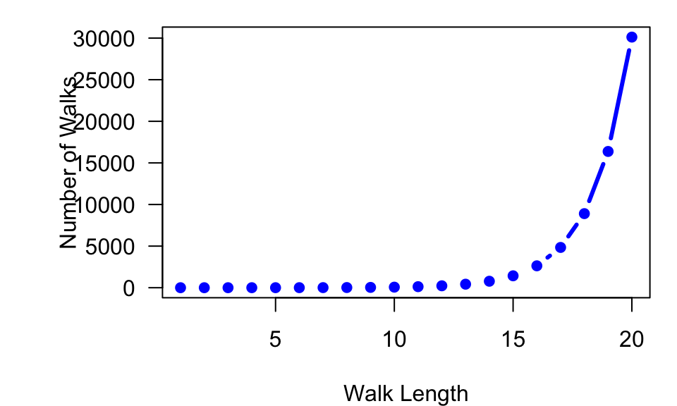

The number of walks from node 3 to 4 increases without bound as the walk length increases, which is termed ‘pathway proliferation’.

```r
# plot the number of walks from node 3 to 4 as walk length increases.
# calculate the number of walks from 3 to 4 as walk length (k) increases.
tw.34 = NA # initialize total walks from 3 to 4
max.w.length = 20
for(k in 1:max.w.length){
  tw = mExp(s$A,k)           # matrix exponetiation [ mExp() is a function in enaR]
  tw.34[k] = tw[3,4]
}

par(las = 1, mar = c(4,6,1,1)) # set plotting parameters

plot(1:max.w.length, tw.34,  # create plot
     type = "b",
     lwd = 3,
     col = "blue",
     pch = 20,
     xlab = "Walk Length",
     ylab = "Number of Walks")
```

## Flow Analysis

Flow anlayses are comprised of methods based on Input–Output Analyses and Information based approaches.

### Input–Output Flow Analyses

This analysis uses the **enaFlow** function.

```r
f = enaFlow(model)
attributes(f)
```

```
## $names
## [1] "T"   "G"   "GP"  "N"   "NP"  "TCC" "TDC" "ns"
```

```r
f$T  # the throughlflow vector
```

```
##           PLANTS         BACTERIA DETRITUS FEEDERS       CARNIVORES
##            11184             5205             2384              370
##         DETRITUS
##            11483
```

```r
f$N  # output oriented flow intensity matrix
```

```
##                  PLANTS   BACTERIA DETRITUS FEEDERS CARNIVORES  DETRITUS
## PLANTS                1 0.43434119       0.19893744 0.03087536 0.9582209
## BACTERIA              0 1.16935117       0.09197564 0.01427474 0.3736137
## DETRITUS FEEDERS      0 0.08420272       1.03856662 0.16118693 0.1857637
## CARNIVORES            0 0.24687724       0.11307499 1.01754939 0.5446477
## DETRITUS              0 0.54697352       0.25052543 0.03888188 1.2067045
```

```r
f$ns # vector of whole-network metrics
```

```
##      Boundary   TST  TSTp      APL        FCI       BFI       DFI
## [1,]    11819 30626 42445 2.591251 0.09193899 0.3859139 0.3035499
##            IFI     ID.F   ID.F.I    ID.F.O    HMG.I   HMG.O AMP.I AMP.O
## [1,] 0.3105362 1.023016 1.414552 0.9126925 2.465946 1.87498     4     0
##      mode0.F  mode1.F  mode2.F  mode3.F mode4.F
## [1,]   11819 15991.28 2815.723 15991.28   11819
```

We can visualize some of our results to better understand them. For example this figure shows the ordered througflow vector (see [Borrett (2013)](http://dx.doi.org/10.1016/j.ecolind.2013.03.014) for one reason for why this might matter).

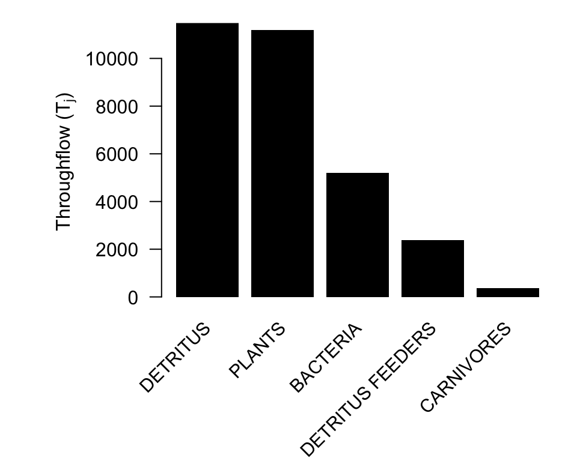

Rank ordered throughflow values for the Cone Springs model.

```r
par(las = 1, mar = c(7,6,0,0),
        oma = c(0,1,1,1), xpd=TRUE)
o = order(f$T, decreasing = TRUE)
bp = barplot(f$T[o], col = "black",
             border = NA, names.arg = NA )
mtext(bquote(paste("Throughflow (",T[j],")")),
        side = 2, las = 3, line = 3.5,
        outer = FALSE)
text(bp,-(.10 * max(f$T)),              # add node names
     labels = names(f$T[o]),
     srt = 45, adj = 1,
     cex = 0.95)
```

The Input-Output flow analysis also calculates the the proportions of system throughFLOW (TST) derived from boundary, direct, and indirect flows. This is a true partition of TST, so we can visualize it as portions of the whole.

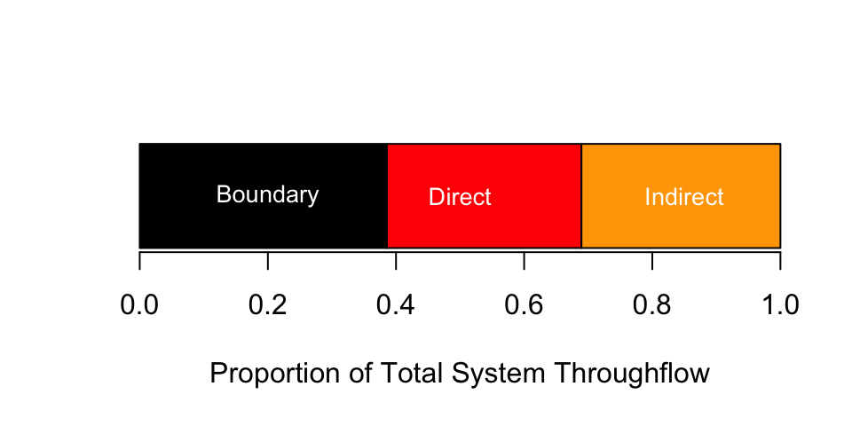

Proportion of Total System ThroughFLOW derived from boundary inputs, direct flows, and indirect flows.

```r
ns = as.data.frame(f$ns)  # lets us access ns by name
flow.partition = as.matrix(c(ns$BFI, ns$DFI, ns$IFI))
bp = barplot(flow.partition, horiz = TRUE, xlim = c(0,1),
        col = c("black","red","orange"),
        xlab = "Proportion of Total System Throughflow")
text(c(0.2,0.5,0.85), bp,
     labels = c("Boundary", "Direct","Indirect"), col = "white", cex = 0.85)
```

### Information Based Flow Analyses

The information based analyses generates a set of whole netowrk metrics that includes informaiton like the *Flow Diversity* (H), *Ascendency* (ASC), the ratio of *Ascendency* and *Capacity* (ASC.CAP), the tetrapartite division of *Ascendnecy*, *Overhead*, and *Capacity* among the *Inputs*, *Internal*, *Respirations*, and *Exports*, as well as the *robustness* measure (A/C * log(A/C)).

```r
enaAscendency(model)
```

```
##            H      AMI       Hr      CAP      ASC       OH   ASC.CAP
## [1,] 3.20096 1.336447 1.864513 135864.7 56725.49 79139.25 0.4175144
##         OH.CAP robustness      ELD       TD  A.input A.internal A.export
## [1,] 0.5824856  0.3646722 1.908258 2.525286 19147.85   29331.98 1051.765
##      A.respiration OH.input OH.internal OH.export OH.respiration CAP.input
## [1,]      7193.894 6221.751    29832.46  7810.812       35274.22   25369.6
##      CAP.internal CAP.export CAP.respiration
## [1,]     59164.44   8862.578        42468.11
```

### Trophic Analyses

Ulanowicz introduced a number of flow analyses to consider food webs including the Lindeman Trophic Spine and the Cycle Distribution. These analyses can be applied as follows. Note that the cycle analysis is computationally intensive and will be slow on larger models.

#### Lindeman Spine

```r
tro = enaTroAgg(model)
attributes(tro)
```

```
## $names
##  [1] "Feeding_Cycles" "A"              "ETL"            "CE"
##  [5] "CR"             "GC"             "RDP"            "LS"
##  [9] "TE"             "ns"
```

```r
tro$ETL  # effective trophic levels
```

```
## [1] 1.00000 2.00000 2.03146 3.03146 1.00000
```

```r
tro$ns   # network metrics
```

```
##           ATL Detrivory DetritalInput DetritalCirc NCYCS NNEX CI
## [1,] 1.812584      7514           635            0     0    0  0
```

#### Cycles

```r
cyc = enaCycle(model)
attributes(cyc)
```

```
## $names
## [1] "Table.cycle"      "Table.nexus"      "CycleDist"
## [4] "NormDist"         "ResidualFlows"    "AggregatedCycles"
## [7] "ns"
```

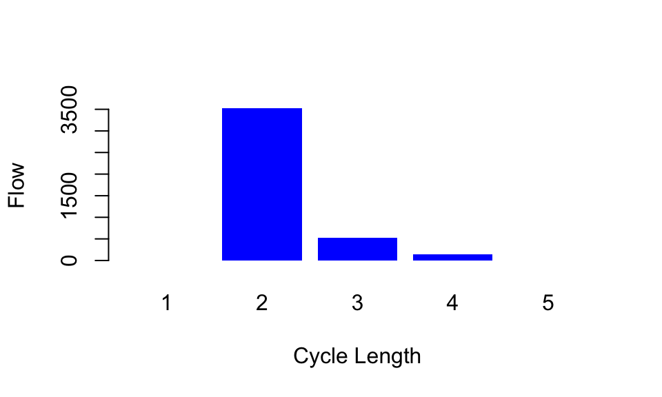

Flow over cycles of increasing lengths.

```r
barplot(cyc$CycleDist, col = "blue", border = NA,
        names.arg = 1:length(cyc$CycleDist),
        ylab = "Flow",
        xlab = "Cycle Length")
```

### Mean Trophic Level

Another common analysis is to calculate the mean trophic level for species above a selected minimum threshold. The *meanTrophicLevel* function was designed for this purpose.

```r
meanTrophicLevel(model, minTL = 2)
```

```
## [1] 2.100115
```

```r
meanTrophicLevel(model, minTL = 3.25)
```

```
## [1] 0
```

## Storage Analysis

Storage is the generic term for the amount of stuff “stored” in each node. If ENA is being applied to a food web model, storage is often synonymous with biomass. This analysis is parallel to the Input-Output flow analysis, but it take the storage (biomass) into account (see [Fath and Borrett 2006](http://dx.doi.org/10.1016/j.envsoft.2004.11.007), [Schramski et al. 2011](http://alpha.math.uga.edu/~caner/pub/Schramski,%20Kazanci,%20Tollner%202011%20NEA%20EcoNet%20v2.pdf).

```r
enaStorage(model)
```

```
## $X
## [1]  285.0  117.0   60.0   17.0 3579.4
##
## $C
##                     PLANTS   BACTERIA DETRITUS FEEDERS CARNIVORES
## PLANTS           -39.24211   0.000000        0.0000000   0.000000
## BACTERIA           0.00000 -44.487179        0.6410256   0.000000
## DETRITUS FEEDERS   0.00000   0.000000      -39.7333333   6.166667
## CARNIVORES         0.00000   0.000000        0.0000000 -21.764706
## DETRITUS           0.00000   1.454154        0.6450802   0.000000
##                   DETRITUS
## PLANTS           31.161404
## BACTERIA         13.675214
## DETRITUS FEEDERS  3.333333
## CARNIVORES        9.823529
## DETRITUS         -3.208080
##
## $P
##                     PLANTS   BACTERIA DETRITUS FEEDERS CARNIVORES
## PLANTS           0.1279532 0.00000000       0.00000000  0.0000000
## BACTERIA         0.0000000 0.01139601       0.01424501  0.0000000
## DETRITUS FEEDERS 0.0000000 0.00000000       0.11703704  0.1370370
## CARNIVORES       0.0000000 0.00000000       0.00000000  0.5163399
## DETRITUS         0.0000000 0.03231454       0.01433512  0.0000000
##                    DETRITUS
## PLANTS           0.69247563
## BACTERIA         0.30389364
## DETRITUS FEEDERS 0.07407407
## CARNIVORES       0.21830065
## DETRITUS         0.92870934
##
## $S
##                      PLANTS    BACTERIA DETRITUS FEEDERS   CARNIVORES
## PLANTS           0.02548283 0.009763289      0.005006815 0.0014185975
## BACTERIA         0.00000000 0.026285127      0.002314823 0.0006558665
## DETRITUS FEEDERS 0.00000000 0.001892741      0.026138422 0.0074058862
## CARNIVORES       0.00000000 0.005549402      0.002845847 0.0467522693
## DETRITUS         0.00000000 0.012295082      0.006305170 0.0017864649
##                    DETRITUS
## PLANTS           0.29868988
```

[output cut: 92 more lines]

```
## BACTERIA          0.17130334
## DETRITUS FEEDERS  0.04367864
## CARNIVORES        0.03628455
## DETRITUS         16.92654477
##
## $dt
## [1] 0.02222222
##
## $ns
##         TSS       CIS        BSI        DSI     ISI     ID.S   ID.S.I
## [1,] 4058.4 0.8477217 0.06471625 0.05363378 0.88165 16.43833 17.07625
##        ID.S.O   HMG.S.O   HMG.S.I NAS NASP  mode0.S  mode1.S  mode2.S
## [1,] 14.38192 0.9422994 0.9971809   4    8 262.6444 355.3617 3440.394
##       mode3.S  mode4.S
## [1,] 355.3617 262.6444
```

Note that the first element in the vector of network statistics is the total system storage (TSS), which for the Cone Springs model is 4058.4 kcal/m2.

The relationship between biodiversity and ecosystem functioning is an important topic in ecology. In an ecosystem network, the nodes represent species, functional groups, or non-living resource books. However, we can apply diversity metrics like the Shannon index to get an approximation of the system biodiversity (see Baird et al. 2011).

```r
biomass = unpack(model)$X
ShannonDiversity(biomass)
```

```
##           H        Hmax          Hr    Hcentral           n effective.n
##   0.4847682   1.6094379   0.3012034   0.6987966   5.0000000   1.6237986
```

*H* is the Shannon Diversity metric, $0 \le H_r \le 1$ is a measure of the evenness, and Hcentral (1 - Hr) is a centralization score that indicates how centralized or concentrated the storage is in a smaller number of nodes.

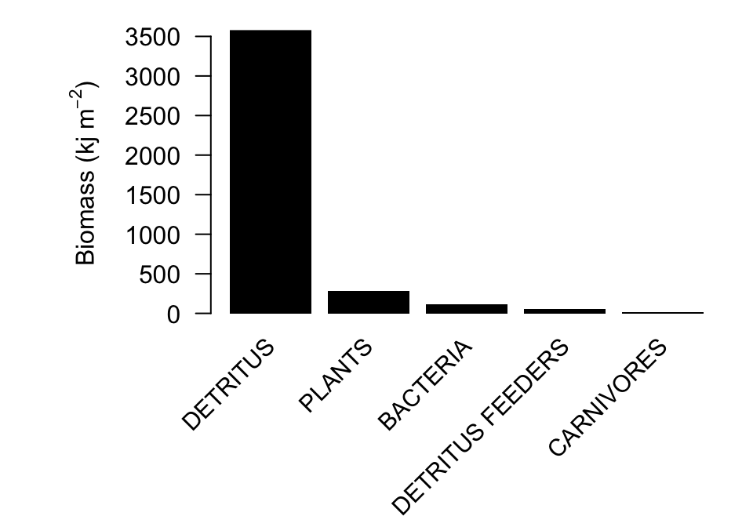

Rank ordered biomass values for the Cone Springs model.

```r
par(las = 1, mar = c(7,6,0,0),
        oma = c(0,1,1,1), xpd=TRUE)
o = order(biomass, decreasing = TRUE)
bp = barplot(biomass[o], col = "black",
             border = NA, names.arg = NA )
mtext(bquote(paste("Biomass (kj ",m^-2,")")),
        side = 2, las = 3, line = 3.5,
        outer = FALSE)
text(bp,-(.10 * max(biomass)),              # add node names
     labels = (model%v%'vertex.names')[o],
     srt = 45, adj = 1,
     cex = 0.95)
```

## Environ Analysis

The environ analysis function finds the 2 x n unit or realized environs for the model. This is a realization of Patten’s environ concept (Patten 1978, 1981).

```r
environs = enaEnviron(model)  # unit input and ouput environs
attributes(environs)
```

```
## $names
## [1] "input"  "output"
```

```r
environs$input
```

```
## $PLANTS
##                  PLANTS BACTERIA DETRITUS FEEDERS CARNIVORES DETRITUS y
## PLANTS               -1        0                0          0        0 1
## BACTERIA              0        0                0          0        0 0
## DETRITUS FEEDERS      0        0                0          0        0 0
## CARNIVORES            0        0                0          0        0 0
## DETRITUS              0        0                0          0        0 0
## z                     1        0                0          0        0 0
##
## $BACTERIA
##                      PLANTS  BACTERIA DETRITUS FEEDERS  CARNIVORES
## PLANTS           -0.9332703  0.000000      0.000000000  0.00000000
## BACTERIA          0.0000000 -1.169351      0.001213296  0.00000000
## DETRITUS FEEDERS  0.0000000  0.000000     -0.038566625  0.01754939
## CARNIVORES        0.0000000  0.000000      0.000000000 -0.01754939
## DETRITUS          0.0000000  1.169351      0.037353329  0.00000000
## z                 0.9332703  0.000000      0.000000000  0.00000000
##                     DETRITUS y
## PLANTS            0.93327028 0
## BACTERIA          0.16813787 1
## DETRITUS FEEDERS  0.02101723 0
## CARNIVORES        0.01754939 0
## DETRITUS         -1.20670450 0
## z                 0.06672972 0
##
## $`DETRITUS FEEDERS`
##                      PLANTS   BACTERIA DETRITUS FEEDERS  CARNIVORES
## PLANTS           -0.9332703  0.0000000       0.00000000  0.00000000
## BACTERIA          0.0000000 -0.2008109       0.03267303  0.00000000
## DETRITUS FEEDERS  0.0000000  0.0000000      -1.03856662  0.01754939
## CARNIVORES        0.0000000  0.0000000       0.00000000 -0.01754939
## DETRITUS          0.0000000  0.2008109       1.00589360  0.00000000
## z                 0.9332703  0.0000000       0.00000000  0.00000000
##                     DETRITUS y
## PLANTS            0.93327028 0
## BACTERIA          0.16813787 0
## DETRITUS FEEDERS  0.02101723 1
## CARNIVORES        0.01754939 0
## DETRITUS         -1.20670450 0
## z                 0.06672972 0
```

[output cut: 17 more lines]

```
## $DETRITUS
##                      PLANTS   BACTERIA DETRITUS FEEDERS  CARNIVORES
## PLANTS           -0.9332703  0.0000000      0.000000000  0.00000000
## BACTERIA          0.0000000 -0.1693512      0.001213296  0.00000000
## DETRITUS FEEDERS  0.0000000  0.0000000     -0.038566625  0.01754939
## CARNIVORES        0.0000000  0.0000000      0.000000000 -0.01754939
## DETRITUS          0.0000000  0.1693512      0.037353329  0.00000000
## z                 0.9332703  0.0000000      0.000000000  0.00000000
##                     DETRITUS y
## PLANTS            0.93327028 0
## BACTERIA          0.16813787 0
## DETRITUS FEEDERS  0.02101723 0
## CARNIVORES        0.01754939 0
## DETRITUS         -1.20670450 1
## z                 0.06672972 0
```

## Control Analysis

A common question in ecosystems concerns who controls whom across the intricate web of interactions. This function applies the control analysis as described in [Schramski et al. (2006)](http://dx.doi.org/10.1016/j.ecolmodel.2005.10.012).

```r
enaControl(model)
```

```
## $CN
##                  PLANTS  BACTERIA DETRITUS FEEDERS CARNIVORES  DETRITUS
## PLANTS                0 0.0000000         0.000000  0.0000000 0.0000000
## BACTERIA              1 0.0000000         0.000000  0.1865961 0.6903851
## DETRITUS FEEDERS      1 0.5806865         0.000000  0.0000000 0.8460570
## CARNIVORES            1 0.0000000         0.891124  0.0000000 0.5486486
## DETRITUS              1 0.0000000         0.000000  0.0000000 0.0000000
##
## $CQ
##                  PLANTS  BACTERIA DETRITUS FEEDERS CARNIVORES  DETRITUS
## PLANTS                0 0.0000000         0.000000  0.0000000 0.0000000
## BACTERIA              1 0.0000000         0.000000  0.1865961 0.6903851
## DETRITUS FEEDERS      1 0.5806865         0.000000  0.0000000 0.8460570
## CARNIVORES            1 0.0000000         0.891124  0.0000000 0.5486486
## DETRITUS              1 0.0000000         0.000000  0.0000000 0.0000000
##
## $CD
##                         PLANTS      BACTERIA DETRITUS FEEDERS
## PLANTS            0.000000e+00  8.344691e-05     8.344691e-05
## BACTERIA         -8.344691e-05  0.000000e+00     2.240311e-05
## DETRITUS FEEDERS -8.344691e-05 -2.240311e-05     0.000000e+00
## CARNIVORES       -8.344691e-05  8.850401e-06    -3.882096e-04
## DETRITUS         -8.344691e-05  7.254992e-05     8.890890e-05
##                     CARNIVORES      DETRITUS
## PLANTS            8.344691e-05  8.344691e-05
## BACTERIA         -8.850401e-06 -7.254992e-05
## DETRITUS FEEDERS  3.882096e-04 -8.890890e-05
## CARNIVORES        0.000000e+00 -5.765539e-05
## DETRITUS          5.765539e-05  0.000000e+00
##
## $CR
##                  PLANTS   BACTERIA DETRITUS FEEDERS CARNIVORES   DETRITUS
## PLANTS                0  1.0000000        1.0000000  1.0000000  1.0000000
## BACTERIA             -1  0.0000000        0.5806865 -0.1865961 -0.6903851
## DETRITUS FEEDERS     -1 -0.5806865        0.0000000  0.8911240 -0.8460570
## CARNIVORES           -1  0.1865961       -0.8911240  0.0000000 -0.5486486
## DETRITUS             -1  0.6903851        0.8460570  0.5486486  0.0000000
##
## $CA
##      PLANTS  BACTERIA DETRITUS FEEDERS CARNIVORES  DETRITUS
```

[output cut: 14 more lines]

```
## $sc
##           PLANTS         BACTERIA DETRITUS FEEDERS       CARNIVORES
##     0.0003337877    -0.0001424441     0.0001934507    -0.0005204615
##         DETRITUS
##     0.0001356673
##
## $psc
##           PLANTS         BACTERIA DETRITUS FEEDERS       CARNIVORES
##         50.35221        -21.48784         29.18223        -78.51216
##         DETRITUS
##         20.46555
##
## $ns
##          TSC
## 0.0006629056
```

## Impact Analyses

There are two forms of what I am calling *Impact Analyses*: Utility Anlaysis and Mixed Trophic Impacts. These analyses can be applied as follows.

```r
u = enaUtility(model)
attributes(u)
```

```
## $names
## [1] "D"               "SD"              "U"               "Y"
## [5] "SY"              "Relations.Table" "ns"
```

```r
u$ns
```

```
##             lam1D relation.change.F synergism.F mutualism.F
## r.change 1.015627             73.33    3.979433       2.125
```

```r
u$Relations.Table
```

```
##                From               To Direct Integral changed
## 1            PLANTS           PLANTS  (0,0)    (+,+)       *
## 2            PLANTS         BACTERIA  (0,0)    (+,+)       *
## 3            PLANTS DETRITUS FEEDERS  (0,0)    (+,+)       *
## 4            PLANTS       CARNIVORES  (0,0)    (+,-)       *
## 5            PLANTS         DETRITUS  (+,-)    (+,-)       -
## 6          BACTERIA         BACTERIA  (0,0)    (+,+)       *
## 7          BACTERIA DETRITUS FEEDERS  (+,-)    (-,-)       *
## 8          BACTERIA       CARNIVORES  (0,0)    (-,+)       *
## 9          BACTERIA         DETRITUS  (-,+)    (-,+)       -
## 10 DETRITUS FEEDERS DETRITUS FEEDERS  (0,0)    (+,+)       *
## 11 DETRITUS FEEDERS       CARNIVORES  (+,-)    (+,-)       -
## 12 DETRITUS FEEDERS         DETRITUS  (-,+)    (-,+)       -
## 13       CARNIVORES       CARNIVORES  (0,0)    (+,+)       *
## 14       CARNIVORES         DETRITUS  (+,-)    (+,+)       *
## 15         DETRITUS         DETRITUS  (0,0)    (+,+)       *
```

```r
mti = enaMTI(model)
attributes(mti)
```

```
## $names
## [1] "G"               "FP"              "Q"               "M"
## [5] "Relations.Table"
```

```r
mti$Relations.Table
```

```
##                From               To Net (direct) Mixed (integral) changed
## 1            PLANTS           PLANTS        (0,0)            (0,0)       -
## 2            PLANTS         BACTERIA        (0,0)            (-,+)       *
## 3            PLANTS DETRITUS FEEDERS        (0,0)            (+,+)       *
## 4            PLANTS       CARNIVORES        (0,0)            (+,+)       *
## 5            PLANTS         DETRITUS        (0,+)            (+,+)       *
## 6          BACTERIA         BACTERIA        (0,0)            (-,-)       *
## 7          BACTERIA DETRITUS FEEDERS        (-,+)            (-,-)       *
## 8          BACTERIA       CARNIVORES        (0,0)            (+,-)       *
## 9          BACTERIA         DETRITUS        (+,-)            (+,-)       -
## 10 DETRITUS FEEDERS DETRITUS FEEDERS        (0,0)            (-,-)       *
## 11 DETRITUS FEEDERS       CARNIVORES        (-,+)            (-,+)       -
## 12 DETRITUS FEEDERS         DETRITUS        (+,-)            (+,-)       -
## 13       CARNIVORES       CARNIVORES        (0,0)            (-,-)       *
## 14       CARNIVORES         DETRITUS        (0,+)            (+,+)       *
## 15         DETRITUS         DETRITUS        (0,0)            (-,-)       *
```

# Other Functions

There are more funcitons in **enaR** than are illustrated in this tutorial. I have illustrated the primary analysis functions, but there are a couple of additional functions that might be of interest to the novice user, which I illustrate here.

## Network Metrics

If you want to get a vector of the network metrics from all of the main ENA functions, you can use the *get.ns* function.

```r
ns = get.ns(model)
show(ns)
```

```
##  n L    C  LD      ppr    lam1A mlam1A      rho         R         d no.scc
##  5 8 0.32 1.6 1.839287 1.839287      1 1.839287 0.6691441 0.2392868      2
##  no.scc.big pscc Boundary   TST  TSTp      APL        FCI       BFI
##           1  0.8    11819 30626 42445 2.591251 0.09193899 0.3859139
##        DFI       IFI     ID.F   ID.F.I    ID.F.O    HMG.I   HMG.O AMP.I
##  0.3035499 0.3105362 1.023016 1.414552 0.9126925 2.465946 1.87498     4
##  AMP.O mode0.F  mode1.F  mode2.F  mode3.F mode4.F       H      AMI
##      0   11819 15991.28 2815.723 15991.28   11819 3.20096 1.336447
##        Hr      CAP      ASC       OH   ASC.CAP    OH.CAP robustness
##  1.864513 135864.7 56725.49 79139.25 0.4175144 0.5824856  0.3646722
##       ELD       TD  A.input A.internal A.export A.respiration OH.input
##  1.908258 2.525286 19147.85   29331.98 1051.765      7193.894 6221.751
##  OH.internal OH.export OH.respiration CAP.input CAP.internal CAP.export
##     29832.46  7810.812       35274.22   25369.6     59164.44   8862.578
##  CAP.respiration    TSS       CIS        BSI        DSI     ISI     ID.S
##         42468.11 4058.4 0.8477217 0.06471625 0.05363378 0.88165 16.43833
##    ID.S.I   ID.S.O   HMG.S.O   HMG.S.I NAS NASP  mode0.S  mode1.S  mode2.S
##  17.07625 14.38192 0.9422994 0.9971809   4    8 262.6444 355.3617 3440.394
##   mode3.S  mode4.S    lam1D relation.change.F synergism.F mutualism.F
##  355.3617 262.6444 1.015627             73.33    3.979433       2.125
##    lam1DS relation.change.S synergism.S mutualism.S
##  13.66567             73.33    4.641385    3.166667
```

```r
length(ns)
```

```
## [1] 81
```

This currently returns a large number (81) whole-network metrics, which can be overwhelming. To get started, I recommend that new investigators pick a small set of metrics to focus upon.

## Run All

Some investigators will appreciate the ease of the *enaAll* function. This runs the most of the major analyses on a model and returns them in one action. However, the function does not execute the *enaTroAgg()* or *enaCycle()* functions because these can be computationally intensive for larger models.

```r
all = enaAll(model)
attributes(all)
```

```
## $names
## [1] "ascendency" "control"    "environ"    "flow"       "mti"
## [6] "storage"    "structure"  "utility"
```

```r
attributes(all$flow)
```

```
## $names
## [1] "T"   "G"   "GP"  "N"   "NP"  "TCC" "TDC" "ns"
```

## Uncertainty Analysis

Applying the uncertainty analysis to a model is a more sophisticated topic that is really beyond the scope of this tutorial. However, given the importance of the methods I include a brief introduction here.

The uncertainty function uses Linear Inverse Modelling to sample the flow parameter space around the original flows in the model. Thus, the user needs to specify an original model, some degree of uncertainty, and a number of samples to return. The simplest way to start with this uncertainty analysis is to specify a single percent change that will be applied all of the flows. As this is a Monte Carlo sampling process, we will a large number of samples (typically about 10,000) to adequately describe the parameter space, but the number depends on several factors and users should determine if this sample size is sufficient.

```r
model.list = enaUncertainty(model, type = "percent", p.err = 25, iter = 10000)
```

```
## Warning in lsei(E = E, F = F, G = G, H = H): No equalities - setting type =
## 2
```

For most models, this code will return 10,000 versions of the original models that have flow values +/- 25% of the original values, and the models should be at steady state. The model.list is a list data object, with one model as each element of the list. Note that this code will typically return a warning message, even if it works correctly.

We can then apply a network analysis across the list.

```r
nsf = lapply(model.list, function(x) enaFlow(x)$ns)  # get the flow network metrics
nsf = as.data.frame(do.call(rbind, nsf))  # reshape the data
mean(nsf$TSTp)
```

```
## [1] 42288.68
```

```r
TSTp.ci95 = quantile(nsf$TSTp, c(0.025,0.975))
show(TSTp.ci95)
```

```
##     2.5%    97.5%
## 36899.85 47776.59
```

More advanced tutorials on the enaUncertainty function are available on the enaR project [GitHub Wiki](https://github.com/SEELab/enaR/wiki).

# Exercises

1. Find the number of nodes and connectance of the *Swartkops Estuary* model.
2. Create a barplot of the throughflow vector of the *Bothnian Sea* model.
3. Plot the node throughflow vs. the effective trophic levels for the *Okefenokee Swamp* food web model.
4. Find the APL, A/C (ASC.CAP), FCI, and TSS of the *Florida Bay (wet)* model.
5. Plot the node storage (biomass) versus estimated trophic levels for the *Gulf of Maine* model.
[^1]: Department of Biology and Marine Biology and Center for Marine Science, University of North Carolina Wilmington & Duke Network Analysis Center, Social Science Research Institute, Duke University